# Low-Dimensional Covariance Regression Applied to HCP Data

Christof Seiler

2017-06-22

## Goal

Apply **low-dimensional** covariance regression model to preprocessed timeseries data from the [Human Connectome Project](https://db.humanconnectome.org/data/projects/HCP_1200).

```r
library(CovRegFC)
```

```r
library(cowplot)
library(ggplot2)
library(reshape2)
library(magrittr)
library(stringr)
library(devtools)
library(rstan)
library(abind)
library(png)
library(cowplot)
library(BatchJobs)
library(coda)
params
```

```
## $num_regions
## [1] "15"
##
## $num_subjects
## [1] "80"
##
## $tp_per_subject
## [1] "Auto"
##
## $num_samples
## [1] "1"
```

## Load HCP Data

Analysis based on data from the WU-Minn HCP 1200 Subjects Data Release with four complete rfMRI runs (with 100% of collected time points). Load subject information and behavioral measurements.

```r
subject_info = read.csv("HCP_PTN820/sample_info.csv")
subject_info = subject_info[,c(
  "Subject",
  "Age",
  "Gender",
  "Acquisition",
  "PSQI_AmtSleep", # amount of sleep in hours
  "PSQI_Score" # Pittsburgh Sleep Quality Index (PSQI) Completed
  )]
```

Classification of sleep duration from Hirshkowitz et al. (2015)[^1]:

- short sleepers: average equal or less than 6 hours each night
- conventional sleepers: average between 7 and 9 hours each night

```r
sleep_duration = rep("undefined",nrow(subject_info))
sleep_duration[subject_info$PSQI_AmtSleep <= 6] = "short"
sleep_duration[(subject_info$PSQI_AmtSleep >= 7) & (subject_info$PSQI_AmtSleep <= 9)] = "conventional"
subject_info$sleep_duration = factor(sleep_duration)
table(subject_info$sleep_duration)
```

```
##
## conventional        short    undefined
##          710          366          130
```

```r
str(subject_info)
```

```
## 'data.frame':    1206 obs. of  7 variables:
##  $ Subject       : int  100004 100206 100307 100408 100610 101006 101107 101208 101309 101410 ...
##  $ Age           : Factor w/ 4 levels "22-25","26-30",..: 1 2 2 3 2 3 1 3 2 2 ...
##  $ Gender        : Factor w/ 2 levels "F","M": 2 2 1 2 2 1 2 1 2 2 ...
##  $ Acquisition   : Factor w/ 13 levels "Q01","Q02","Q03",..: 6 11 1 3 8 6 6 12 6 6 ...
##  $ PSQI_AmtSleep : num  5 6 6.5 8 7 7 4 7 5.5 5.5 ...
##  $ PSQI_Score    : int  8 6 4 4 4 2 9 6 5 8 ...
##  $ sleep_duration: Factor w/ 3 levels "conventional",..: 2 2 3 1 1 1 2 1 2 2 ...
```

Load timeseries.

```r
num_regions = as.integer(params$num_regions)
num_regions
```

```
## [1] 15
```

```r
channel_names = paste0("R",1:num_regions)
path = paste0("HCP_PTN820/node_timeseries/3T_HCP820_MSMAll_d",num_regions,"_ts2")
file_names = list.files(path = path,pattern = ".txt")
file_subject_ids = strsplit(file_names,split = ".txt") %>% unlist
ts = lapply(file_subject_ids,function(Subject) {
  print(paste("reading subject:",Subject))
  full_path = paste0(path,"/",Subject,".txt")
  timeseries = read.csv(full_path,header = FALSE,sep = " ")
  timeseries$Subject = Subject
  timeseries
}) %>% do.call(rbind,.) %>% data.frame
```

[output not shown]

[output cut: 805 more lines]

```r
names(ts)[1:num_regions] = channel_names
```

Merge timeseries and subject info into one data frame.

```r
ts_subject_info = merge(ts,subject_info,by = "Subject")
```

Plot timeseries for one subject.

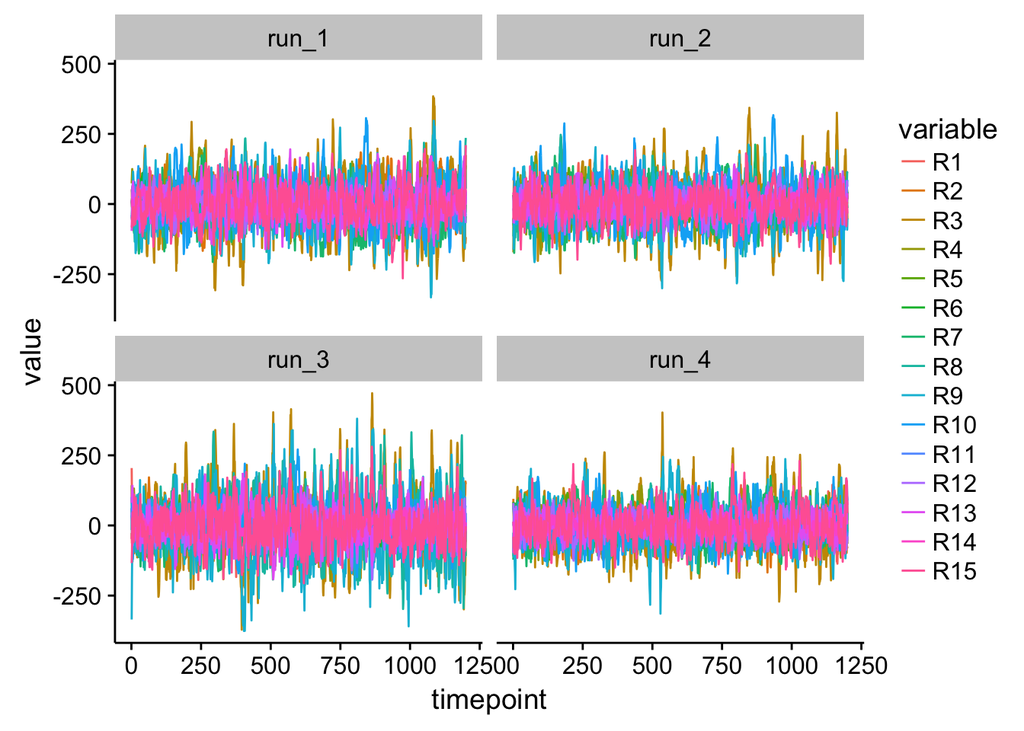

```r
subject_names = names(table(ts_subject_info$Subject))
timeseries = subset(ts_subject_info,Subject == subject_names[1])
timeseries$timepoint = rep(1:(nrow(timeseries)/4),4)
timeseries$run = lapply(paste0("run_",1:4),function(i) rep(i,nrow(timeseries)/4)) %>% unlist
timeseries_long = melt(timeseries,id.vars = c("timepoint","run",names(subject_info)))
ggplot(timeseries_long,aes(x = timepoint,y = value,color = variable)) +
  geom_line() + facet_wrap(~run)
```

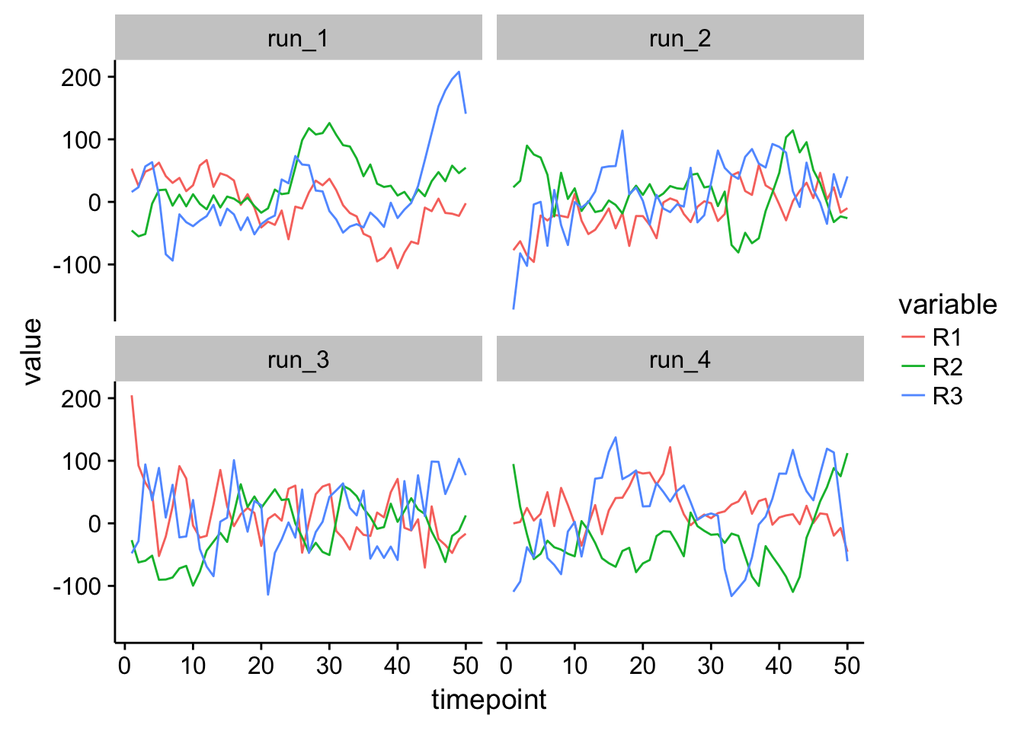

```r
timeseries_long_subset = subset(timeseries_long,
                                timepoint < 51 & (variable == "R1" | variable == "R2" | variable == "R3"))
ggplot(timeseries_long_subset,aes(x = timepoint,y = value,color = variable)) +
  geom_line() + facet_wrap(~run)
```

What is the effective samples size computed using autocorrelation function.

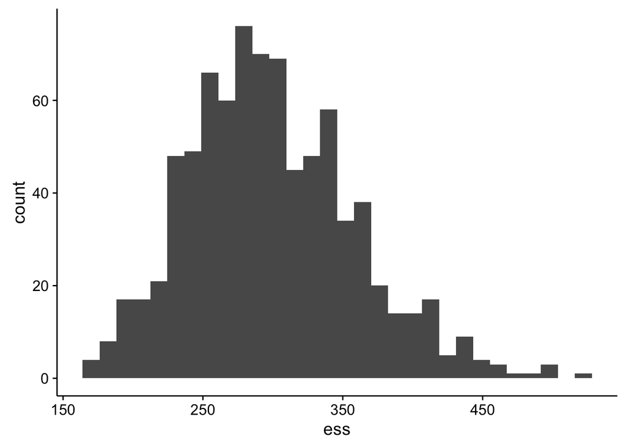

```r
run = cut_number(1:nrow(timeseries), 4, labels=FALSE)
ess = lapply(subject_names,function(subject_name) {
  sapply(1:4,function(i) {
    timeseries = subset(ts_subject_info,Subject == subject_name)
    Y = timeseries[run==i,channel_names]
    effectiveSize(Y) %>% min
  })  %>% sum
}) %>% unlist
df = data.frame(subject_id=1:length(ess),ess)
ggplot(df,aes(ess)) + geom_histogram()
```

```r
tp_per_subject = round(min(df$ess))
tp_per_subject
```

```
## [1] 167
```

Subsample time points within each subject to account for dependencies.

```r
#tp_per_subject = as.integer(params$tp_per_subject)
#tp_per_subject
ts_subject_info_subset = subset(ts_subject_info,
                                sleep_duration == "short" | sleep_duration == "conventional") %>% droplevels
subject_names = names(table(ts_subject_info_subset$Subject))
subsample_ids = lapply(subject_names,function(subject_name) {
  ids = which(ts_subject_info_subset$Subject == subject_name)
  seq(from = min(ids),to = max(ids),length.out = tp_per_subject) %>% floor
}) %>% unlist
ts_subject_info_subset = ts_subject_info_subset[subsample_ids,] %>% droplevels
str(ts_subject_info_subset)
```

```
## 'data.frame':    121910 obs. of  22 variables:
##  $ Subject       : chr  "100206" "100206" "100206" "100206" ...
##  $ R1            : num  53.1 26.6 47.1 48.7 52.9 ...
##  $ R2            : num  -45.7 110 -16.2 -28.1 41.6 ...
##  $ R3            : num  15.8 16.8 -153 58.5 24.2 ...
##  $ R4            : num  74 -20.8 -39.7 50.5 90.3 ...
##  $ R5            : num  9.81 53.45 -19.24 -46.09 -92.13 ...
##  $ R6            : num  15.8 57.7 -36.5 -50.4 -87.1 ...
##  $ R7            : num  6.83 -127.34 26.82 -81.19 -44.93 ...
##  $ R8            : num  44.6 -18.9 -36.7 -60.7 62.6 ...
##  $ R9            : num  -44.7 -33.3 -45.4 156 12 ...
##  $ R10           : num  -41 35.7 42.3 -57.8 -1.2 ...
##  $ R11           : num  3.58 -38.95 23.69 47.86 17.75 ...
##  $ R12           : num  12.91 -20.89 59.28 -64.38 7.05 ...
##  $ R13           : num  -95.77 -70.64 -8.49 -3.9 62.22 ...
##  $ R14           : num  13.12 8.83 -30.12 60.29 -43.07 ...
##  $ R15           : num  -76.9 30.1 -34.1 33.5 -36.3 ...
##  $ Age           : Factor w/ 4 levels "22-25","26-30",..: 2 2 2 2 2 2 2 2 2 2 ...
##  $ Gender        : Factor w/ 2 levels "F","M": 2 2 2 2 2 2 2 2 2 2 ...
##  $ Acquisition   : Factor w/ 12 levels "Q01","Q02","Q03",..: 11 11 11 11 11 11 11 11 11 11 ...
##  $ PSQI_AmtSleep : num  6 6 6 6 6 6 6 6 6 6 ...
##  $ PSQI_Score    : int  6 6 6 6 6 6 6 6 6 6 ...
##  $ sleep_duration: Factor w/ 2 levels "conventional",..: 2 2 2 2 2 2 2 2 2 2 ...
```

```r
table(ts_subject_info_subset$Subject)
```

```
##
## 100206 100408 100610 101006 101107 101309 102008 102513 102816 103111
##    167    167    167    167    167    167    167    167    167    167
## 103414 103515 104012 104416 104820 105014 105115 105216 105620 105923
##    167    167    167    167    167    167    167    167    167    167
## 106016 106319 106521 107018 107321 107422 107725 108121 108222 108323
##    167    167    167    167    167    167    167    167    167    167
## 108525 108828 109123 109830 110007 110411 110613 111312 111413 111514
##    167    167    167    167    167    167    167    167    167    167
## 111716 112112 112314 112516 112920 113215 113619 113922 114217 114318
##    167    167    167    167    167    167    167    167    167    167
## 114419 114621 114823 114924 115017 115219 115320 115825 116524 116726
##    167    167    167    167    167    167    167    167    167    167
## 117122 117324 118023 118124 118225 118528 118730 118932 119126 120111
##    167    167    167    167    167    167    167    167    167    167
```

[output cut: 132 more lines]

```r
ct = table(ts_subject_info_subset[,c("Acquisition","sleep_duration")])/tp_per_subject
addmargins(ct)
```

```
##            sleep_duration
## Acquisition conventional short Sum
##         Q01           28    12  40
##         Q02           48    14  62
##         Q03           40    30  70
##         Q04           53    26  79
##         Q05           37    37  74
##         Q06           55    31  86
##         Q07           45    15  60
##         Q08           42    20  62
##         Q09           41    14  55
##         Q10           46    22  68
##         Q11           46    18  64
##         Q12            8     2  10
##         Sum          489   241 730
```

Subsample subject for power curve.

```r
subsample_subjects = function(ts_subject_info_subset,
                              num_subjects,
                              seed = 934321) {
  set.seed(seed)
  total_samples = table(ts_subject_info_subset$sleep_duration)/table(ts_subject_info_subset$Subject)[1]
  num_subject_short = ceiling(num_subjects * total_samples["short"] / sum(total_samples))
  num_subject_conventional = num_subjects-num_subject_short
  short_names = subset(ts_subject_info_subset,sleep_duration == "short")$Subject %>%
    table %>% names %>% sample(.,num_subject_short)
  conventional_names = subset(ts_subject_info_subset,sleep_duration == "conventional")$Subject %>%
    table %>% names %>% sample(.,num_subject_conventional)
  subject_names = c(short_names,conventional_names)
  ts_subject_info_subset[ts_subject_info_subset$Subject %in% subject_names,]
}
```

## Low-Dimensional Covariance Modeling

We can account for correlation between the error terms of the multivariate response variable using covariance regression model. Repeat many times for power curve.

```r
condition = "sleep_duration"
ts_subject_info_subset = within(ts_subject_info_subset,
                                sleep_duration <- relevel(sleep_duration, ref = "conventional"))
num_subjects = as.integer(params$num_subjects)
num_samples = as.integer(params$num_samples)
log_name = paste0("HCP_low_",num_regions,"_",num_subjects,"_",tp_per_subject)
if(dir.exists(log_name)) unlink(log_name,recursive = TRUE) # cleanup
reg = makeRegistry(id = log_name, file.dir = log_name)
```

```
## Creating dir: HCP_low_15_80_167
```

```
## Saving registry: /Users/cseiler/CovRegFC_HCP/HCP_low_15_80_167/registry.RData
```

```r
batchExport(reg, li = list(channel_names = channel_names,
                           condition = condition,
                           overwrite = TRUE))
fun = function(data) {
  library(CovRegFC)
  CovRegFC::covreg_low(data = data,
                       response = channel_names,
                       condition = condition)
}
if(is.na(num_subjects)) {
  batchMap(reg, fun, ts_subject_info_subset)
} else {
  data = lapply(1:num_samples,function(seed) {
    subsample_subjects(ts_subject_info_subset,
                       num_subjects = num_subjects,
                       seed = seed)
  })
  batchMap(reg, fun, data)
}
```

```
## Adding 1 jobs to DB.
```

```r
submitJobs(reg)
```

```
## Saving conf: /Users/cseiler/CovRegFC_HCP/HCP_low_15_80_167/conf.RData
```

```
## Submitting 1 chunks / 1 jobs.
```

```
## Cluster functions: Interactive.
```

```
## Auto-mailer settings: start=none, done=none, error=none.
```

```
## Loading registry: /Users/cseiler/CovRegFC_HCP/HCP_low_15_80_167/registry.RData
```

```
## Loading RData files: channel_names,condition,overwrite
```

```
## Loading conf: /Users/cseiler/CovRegFC_HCP/HCP_low_15_80_167/conf.RData
```

```
## 2017-06-22 17:25:00: Starting job on node Christofs-MacBook-Pro-2.local.
```

```
## Auto-mailer settings: start=none, done=none, error=none.
```

```
## Setting work dir: /Users/cseiler/CovRegFC_HCP
```

```
## Loading jobs from file '/Users/cseiler/CovRegFC_HCP/HCP_low_15_80_167/jobs/01/1.rds'
```

```
## ########## Executing jid=1 ##########
```

```
## Timestamp: 2017-06-22 17:25:00
```

```
## Setting seed: 963208816
```

```
## The following numerical problems occurred the indicated number of times on chain 1
```

[output not shown]

```
## When a numerical problem occurs, the Hamiltonian proposal gets rejected.
```

```
## See http://mc-stan.org/misc/warnings.html#exception-hamiltonian-proposal-rejected
```

```
## If the number in the 'count' column is small, there is no need to ask about this message on stan-users.
```

```
## Writing result file: /Users/cseiler/CovRegFC_HCP/HCP_low_15_80_167/jobs/01/1-result.RData
```

```
## 2017-06-22 18:28:38: All done.
```

```
## Setting work back to: /Users/cseiler/CovRegFC_HCP
```

```
## Memory usage according to gc:
```

```
## Sending 1 submit messages...
## Might take some time, do not interrupt this!
```

```r
waitForJobs(reg,sleep = 360)
```

```
## Syncing registry ...
```

```
## [1] TRUE
```

```r
fit_list = reduceResultsList(reg)
```

```
## Reducing 1 results...
```

```r
save(fit_list,file = paste0("fit_list_low_",num_regions,"_",num_subjects,"_",tp_per_subject,".Rdata"))
fit = fit_list[[1]]
```

Traceplots to assess convergence of HMC sampler.

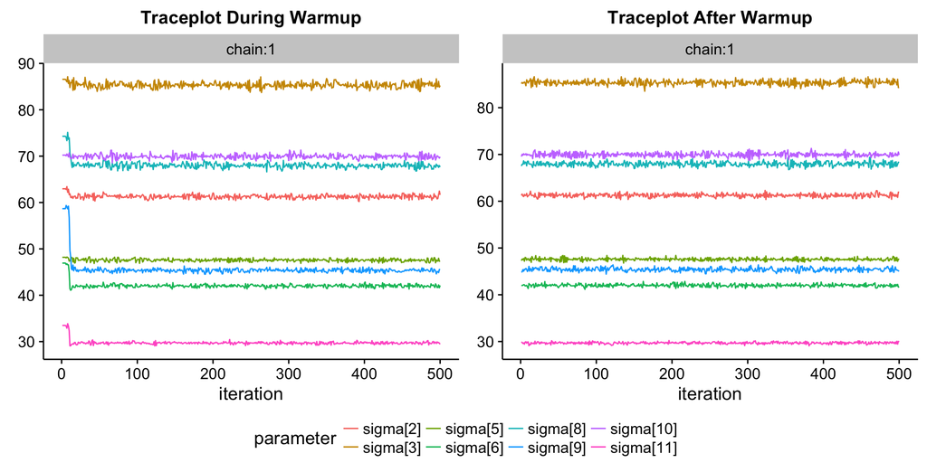

```r
CovRegFC::plot_diagnostics(fit,par_name = "sigma",num_par = 8)
```

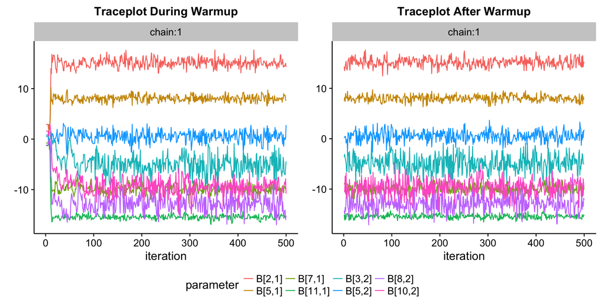

```r
CovRegFC::plot_diagnostics(fit,par_name = "B",num_par = 8)
```

## Visualize Results

Plot regions.

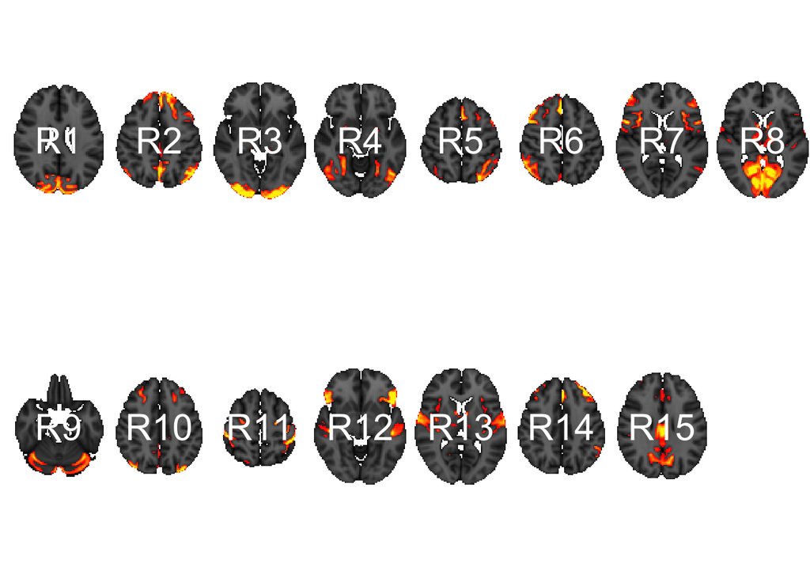

```r
path = paste0("HCP_PTN820/groupICA/groupICA_3T_HCP820_MSMAll_d",num_regions,".ica/melodic_IC_sum.sum")
pngs = list.files(path = path,pattern = ".png")
full_paths = paste(path,pngs,sep = "/")
ps = lapply(1:length(full_paths),function(i)
  CovRegFC::plot_brain(full_paths[i],title = paste0("R",i))
)
p_brains = do.call(plot_grid,c(ps,nrow = 2))
p_brains
```

```r
ggsave(p_brains,filename = paste0("brains_",num_regions,".pdf"),width = 9,height = 3)
```

Analyze posterior covariance **explained** by simulation conditions.

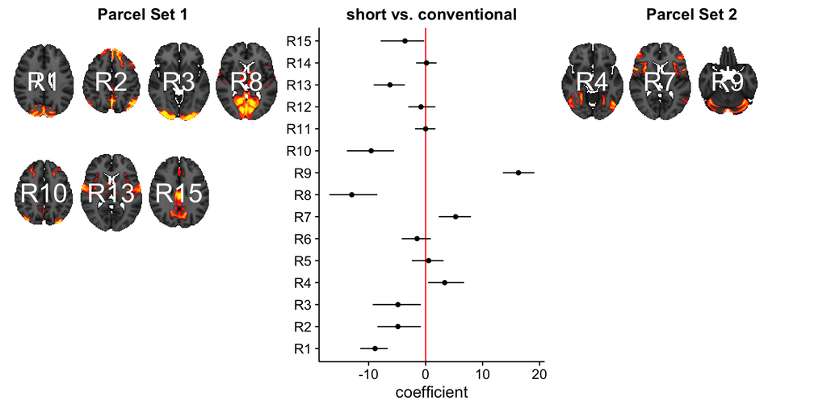

```r
condition_names = ts_subject_info_subset[,condition] %>% contrasts %>% rownames %>% rev
title = paste(condition_names,collapse = " vs. ")
p_brain_coeff = CovRegFC::plot_coeff(fit,
                                     response = channel_names,
                                     alpha = 0.05/length(channel_names),
                                     title = title,
                                     brain_slices = full_paths)
p_brain_coeff
```

```r
ggsave(p_brain_coeff,filename = paste0("brains_coeff_",num_regions,"_",num_subjects,"_",tp_per_subject,".pdf"),
       height = 5,width = 10)
```

```
##  setting  value
##  version  R version 3.3.2 (2016-10-31)
##  system   x86_64, darwin13.4.0
##  ui       X11
##  language (EN)
##  collate  en_US.UTF-8
##  tz       America/Los_Angeles
##  date     2017-06-22
```

```
## Packages -----------------------------------------------------------------
```

[output not shown]

[output cut: 67 more lines]

[output not shown]

[^1]: Hirshkowitz et al. (2015), National Sleep Foundation’s sleep recommendations: Methodology and results summary, Sleep Health.